# Confidence intervals

PCB 6455 / BSC 4933: Biometry | Lecture 17

Dr. Brian Maitner

## Today’s agenda

- **Check-in**: how the course is going, ten minutes
- **Two from the quiz**: why the minus sign, and the two halves of a model
- Every number so far has been a single best guess. **How sure are we?**
- One parameter: where an interval comes from, and why 1.92
- Two parameters: **profiles**, and the shortcut that lies
- Intervals on Thursday’s bobwhite fits

Type and run on a code block: type it into your script and run it. You will need it later. Code without the label is there to watch.

# Mid-semester check-in

## How is it going?

Half the semester is done.

1. **Anything that is working** and should stay
2. **Anything that should change**
3. **The pace**: too fast, about right, or too slow?
4. Anything you wish there were **more** of: examples, practice problems, assignments, office hours?

## Optional extras: what would you use?

I am writing **optional supplements** for things the course does not have time for. Self-paced, nothing graded. The first is up: *Figures worth showing*, in `supplements/`.

A. Where distributions come from  
B. Getting messy data into shape  
C. Finding data, and APIs  
D. Maps and geospatial data

E. Competition and dynamic models  
F. Writing your own R package  
G. Reproducible pipelines

A few questions:

- **Which (if any) are most useful?**
- **Which would make you sign up for a second biometry course?**
- **Any other requests?**

# Two from the quiz

## Why the **negative**?

Same curve, same information. The only difference is the sign.

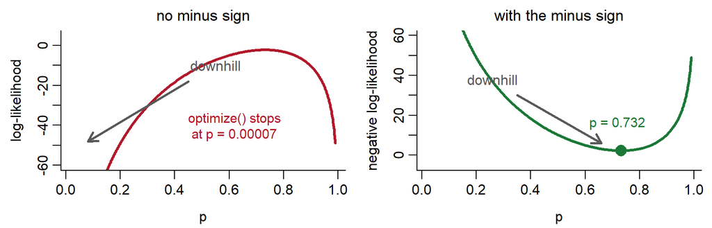

`optimize()` and `optim()` **walk downhill**. The minus is what puts the answer we want at the bottom, where they are looking.

## What happens without it

52 of 71 routes held bobwhite in 2019. Leave the minus off:

```r
ll <- function(p){ dbinom(52, size = 71, prob = p, log = TRUE) }    # no minus

optimize(ll, interval = c(0, 1))$minimum
```

```
[1] 6.610696e-05
```

**p is essentially zero**: the fit says bobwhite are on none of the routes, when they were on 52 of them. No error. No warning. Just a wrong answer.

```r
nll <- function(p){ -dbinom(52, size = 71, prob = p, log = TRUE) }  # minus

optimize(nll, interval = c(0, 1))$minimum
```

```
[1] 0.7323749
```

`optimize()` has a `maximum = TRUE`, so here you could go either way. **`optim()` and `mle2()` do not.** They minimize, always, which is why we always write the negative.

## A model is two things

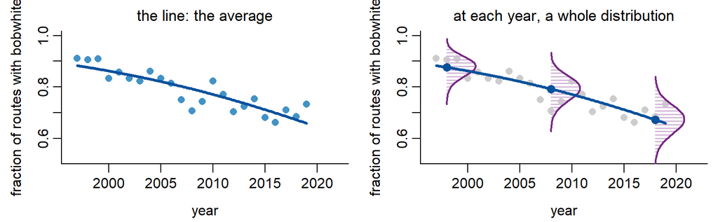

The **deterministic function** is the line: the average you expect in a given year. The **distribution** is the purple shape standing on it: how far one real survey lands from that average.

## Both halves are in the code you wrote

Thursday’s occupancy model, with the two halves labeled:

```r
occ_nll <- function(params, n_occupied, n_routes, elapsed){

  p <- plogis(params[1] + params[2] * elapsed)   # the function: the average

  -sum(dbinom(n_occupied,                        # the distribution: the scatter
              size = n_routes,
              prob = p,
              log = TRUE))
}
```

# How sure are we?

## Where we are

| Section | Question | When |
| --- | --- | --- |
| 6.1 - 6.2 | What parameter values make my data most likely? | Last Tuesday |
| 6.3 | What if the parameter depends on a covariate? | Last Thursday |
| **6.4 - 6.5** | **How sure am I about that parameter?** | **Today** |
| 6.6 | Which of two models is better? | This Thursday |

Same negative log-likelihood. **Today we read its shape**, not just its lowest point.

## 6% a year, give or take what?

Thursday’s occupancy fit gave $b = -0.062$: the odds that a route holds bobwhite fall about **6% a year**.

Suppose the truth were 6% give or take 1%. Or give or take 10%.

| If the range is | Then |
| --- | --- |
| falling 5% to 7% a year | a clear, steady decline, worth acting on |
| anything from rising 4% to falling 16% | it might be **increasing**; we do not know |

**Same best guess. Opposite conclusions.** The range is what tells them apart.

## What is a confidence interval?

A **range of parameter values consistent with the data**, reported instead of a single best guess.

You have seen them in polls: “48% support, **plus or minus 3 points**” is a confidence interval of 45% to 51%.

Three parts:

- the **estimate**, the best guess
- a **lower** and an **upper limit**
- a **confidence level**, usually 95%

**Narrow:** the data pin the value down. **Wide:** they don’t.

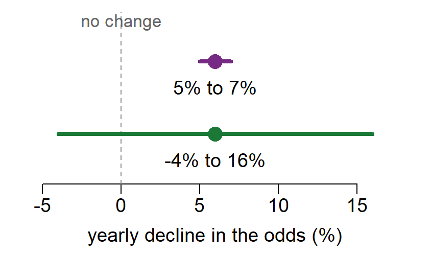

Today’s question is where the two limits come from. Short answer: **they are the values the data cannot rule out.**

## Start with one parameter

Back to the simplest version: **52 of the 71 routes** surveyed in 2019 held bobwhite.

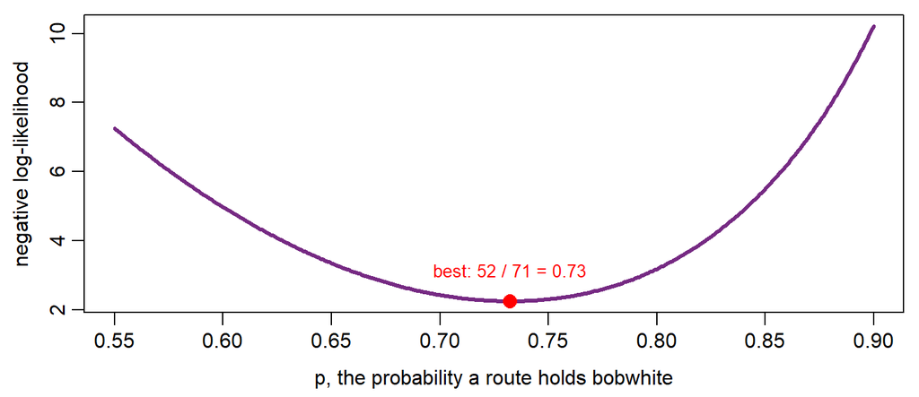

The best value is 0.73. **But 0.72 is barely worse. How far from the bottom is too far?**

## Get set up

```r
library(bbmle)

occ <- read.csv("https://github.com/bmaitner/biometry_course/raw/refs/heads/main/data/class_examples/bobwhite_occupancy.csv")
counts <- read.csv("https://github.com/bmaitner/biometry_course/raw/refs/heads/main/data/class_examples/bobwhite_counts.csv")

nll_2019 <- function(p){
  -dbinom(52, size = 71, prob = p, log = TRUE)
}

p_vec <- seq(0.55, 0.90, by = 0.001)    # candidate values of p
nll_vec <- nll_2019(p_vec)               # dbinom takes all of them at once

plot(p_vec, nll_vec, type = "l", xlab = "p", ylab = "negative log-likelihood")
```

## Drawing the line

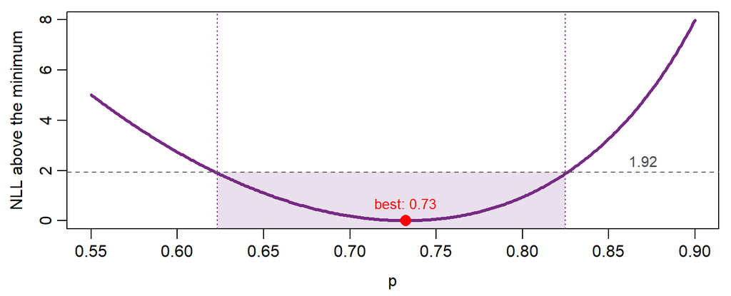

Keep every value of $p$ whose NLL is **within 1.92** of the minimum: the values the data cannot rule out. That range is the **95% confidence interval**.

## Where 1.92 comes from

Compare the best value with any other value $p_0$:

$$\text{deviance} = 2 \times \big(\text{NLL}(p_0) - \text{NLL}_{\text{best}}\big)$$

If $p_0$ **is the true value**, that deviance follows a known distribution: a **chi-squared with 1 degree of freedom**. One degree of freedom because we fixed one parameter.

```r
qchisq(0.95, df = 1)       # deviance the true value exceeds only 5% of the time
qchisq(0.95, df = 1) / 2   # the same threshold, in NLL units
```

Values within 1.92 cannot be ruled out. Values beyond it can, at the 5% level. That is a **likelihood ratio test** run on every candidate value at once.

## Find the interval

```r
best <- min(nll_vec)                  # the bottom of the curve

in_range <- nll_vec <= best + 1.92    # TRUE for every p within 1.92 of it

range(p_vec[in_range])                # the smallest and largest p that passed
```

**Check:** you should get about **0.623 to 0.825**.

Is the interval **symmetric** around 0.73?

## The shortcut, and when it breaks

The interval you have seen in every stats class: **estimate ± 1.96 standard errors**.

```r
p_hat <- 52 / 71
se <- sqrt(p_hat * (1 - p_hat) / 71)    # standard error of a proportion
p_hat + c(-1.96, 1.96) * se
```

|  | from the curve | ± 1.96 SE |
| --- | --- | --- |
| bobwhite, 52 of 71 | 0.623 to 0.825 | 0.629 to 0.835 |
| Eastern Wood-Pewee, 3 of 71 | 0.011 to 0.105 | **-0.005** to 0.089 |

Change the 52 to 3 and try it. **A negative probability.**

## Why the shortcut breaks

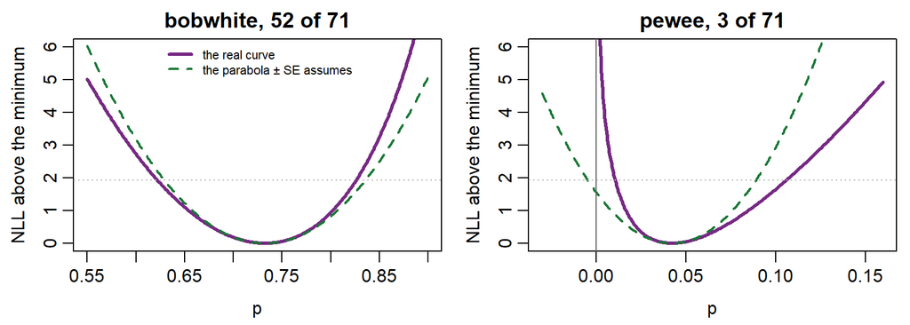

The standard error **pretends the curve is a parabola**. Symmetric, and blind to the edge at zero.

## Two parameters

Thursday’s occupancy curve has **two**: where it starts, $a$, and how fast it falls, $b$.

How sure are we about $b$?

## Get set up, again

Thursday’s fit, with `mle2()`:

```r
occ_nll2 <- function(params, n_occupied, n_routes, elapsed){
  p <- plogis(params[1] + params[2] * elapsed)
  -sum(dbinom(n_occupied, size = n_routes, prob = p, log = TRUE))
}
parnames(occ_nll2) <- c("a", "b")

occ_data <- list(n_occupied = occ$n_occupied,
                 n_routes = occ$n_routes,
                 elapsed = occ$elapsed)

m_occ <- mle2(minuslogl = occ_nll2, start = c(a = 2, b = -0.05),
              data = occ_data)
coef(m_occ)
m_occ@min      # the lowest NLL it found
```

**Check:** $a$ = 2.018, $b$ = -0.0619, NLL 56.69, as on Thursday.

## The surface

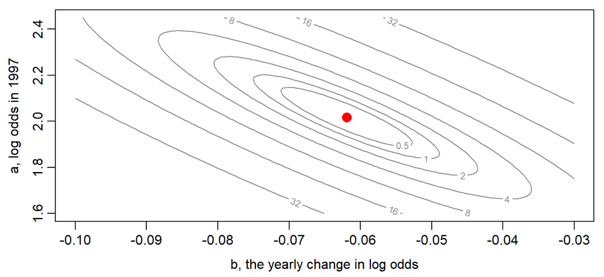

A **tilted** valley. Correlation between the estimates: **-0.89**.

## Slices and profiles

To ask about $b$ alone, walk across the surface along $b$. **What do we do with $a$?**

**A slice**

Hold $a$ at its best value. Compute the NLL.

Cheap. No optimizer.

**A profile**

At each $b$, **re-fit $a$**. Keep the best NLL.

One optimization per value of $b$.

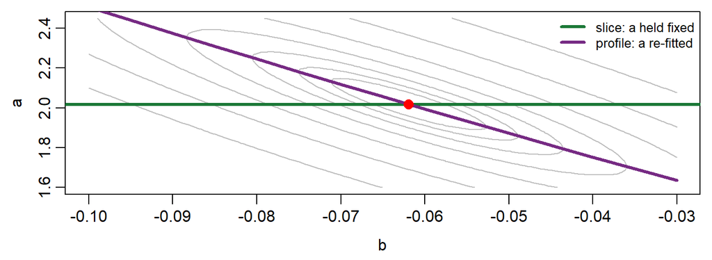

## Your turn, part 1: the profile

```r
b_vec <- seq(-0.10, -0.03, by = 0.005)
prof_nll <- numeric(length(b_vec))       # to hold the answers

for (i in seq_along(b_vec)) {
  fit_i <- mle2(minuslogl = occ_nll2,
                start = c(a = 2, b = -0.05),
                fixed = list(b = b_vec[i]),    # b held here; a is re-fitted
                data = occ_data)
  prof_nll[i] <- fit_i@min
}

plot(b_vec, prof_nll - m_occ@min, type = "b", ylim = c(0, 10),
     xlab = "b", ylab = "NLL above the minimum")
abline(h = 1.92, lty = 2)
```

## Your turn, part 2: the slice

Now the slice, on the **same plot**: hold $a$ at its best value instead of re-fitting it.

```r
a_hat <- coef(m_occ)["a"]
slice_nll <- numeric(length(b_vec))

for (i in seq_along(b_vec)) {
  # the NLL with a set to a_hat and b set to b_vec[i]
  # (no optimizer: nothing is being fitted. occ_nll2 wants
  #  a vector of both parameters, then the three data columns)
}

points(b_vec, slice_nll - m_occ@min, type = "b", col = "red")
```

**Which curve gives the narrower interval? Why?**

## The slice is overconfident

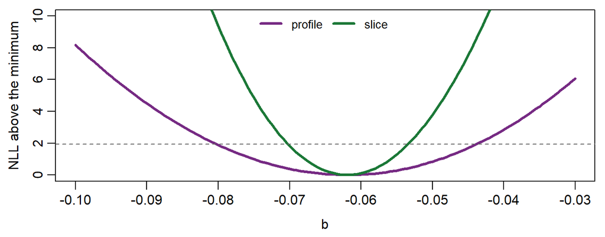

|  | 95% interval for $b$ | width |
| --- | --- | --- |
| slice | -0.070 to -0.054 | 0.016 |
| **profile** | **-0.080 to -0.044** | **0.036** |

The slice **pretends we know $a$ exactly**. We don’t, so its interval is too narrow by more than half.

## The one-line version

`mle2` will build every profile for you:

```r
confint(m_occ)                    # profile intervals for every parameter
confint(m_occ, method = "quad")   # the ± 1.96 SE shortcut, for comparison
```

| method | b_lower | b_upper |
| --- | --- | --- |
| profile (`confint`) | -0.0802 | -0.0439 |
| ± 1.96 SE (`quad`) | -0.0800 | -0.0438 |

Nearly identical **here**: 1,730 route-surveys make the surface close to a parabola. When they disagree, believe the profile.

## What the interval means

The interval is on the **log odds** scale. Back-transform the **endpoints**, as on Thursday:

```r
exp(confint(m_occ)["b", ])        # yearly multiplier on the odds
```

The odds of occupancy are multiplied by **0.923 to 0.957** each year.

So they fall by between **4.3% and 7.7% a year**, best guess 6%.

**Zero is not in the interval for $b$.** So a flat line, $b = 0$, is ruled out at the 5% level: an interval and a test are the same calculation.

## How sure about development?

Thursday’s abundance model, now with `mle2` so `confint()` works:

```r
urban_nll2 <- function(params, y, u){
  mu <- params[1] * exp(params[2] * u)
  -sum(dnbinom(y, mu = mu, size = params[3], log = TRUE))
}
parnames(urban_nll2) <- c("mu0", "b", "size")

m_urban <- mle2(minuslogl = urban_nll2,
                start = c(mu0 = 12, b = -3, size = 1.4),
                data = list(y = counts$count, u = counts$frac_built),
                method = "L-BFGS-B",
                lower = c(mu0 = 0.1, b = -20, size = 0.05),
                upper = c(mu0 = 100, b = 20, size = 50))

confint(m_urban)
```

**Is zero inside the interval for `b`?**

## What it means

| parameter | estimate | lower | upper |
| --- | --- | --- | --- |
| mu0 | 12.129 | 11.511 | 12.789 |
| b | -3.226 | -3.787 | -2.653 |
| size | 1.476 | 1.360 | 1.602 |

Bobwhite counts halve with every **18% to 26%** of development. Thursday’s single answer was 21%.

## What “95%” means

Pretend we know the truth: $p = 0.73$. Survey 71 routes, 100 separate times, and compute an interval each time.

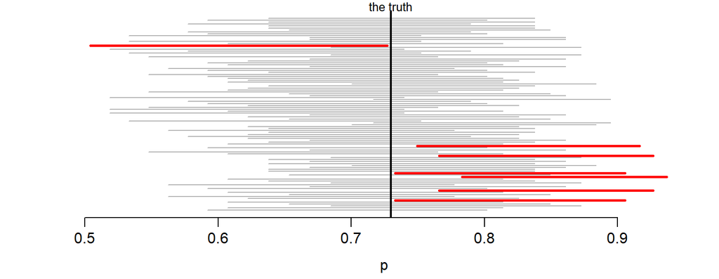

**7 of 100** miss. The **method** catches the truth about 95% of the time. Any **one** interval either contains it or doesn’t.

## From the parameters to the curve

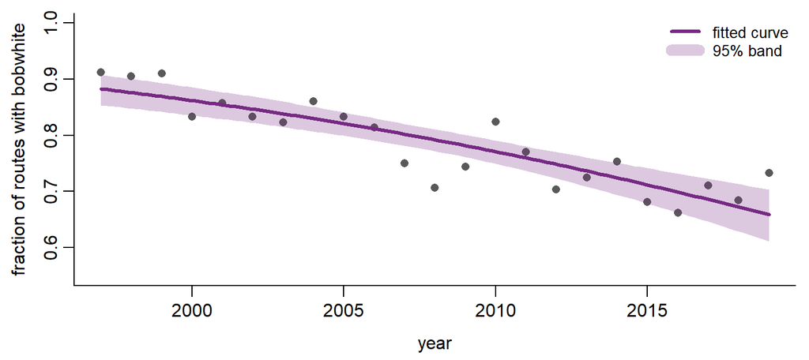

The intervals on $a$ and $b$ become an interval on **the whole curve**. How to draw it is **Lecture 21**.

## What you can now do

- Read an interval off a likelihood curve: everything **within 1.92** of the minimum
- Say where 1.92 comes from: half of `qchisq(0.95, 1)`
- Know when **± 1.96 SE** is fine, and when it gives impossible answers
- Build a **profile**, and know why a **slice** is overconfident
- `confint()` an `mle2` fit, and **back-transform the endpoints**

Still missing: **is the more complicated model worth it?** That is this Thursday.

## Additional practice

Make the coverage plot yourself. Same ideas, less handholding:

```r
# 1. one imaginary survey: 71 routes, true p of 0.73
k <- rbinom(1, size = 71, prob = 0.73)
# 2. its interval, by the method from earlier: an NLL curve over p_vec,
#    then the values within 1.92 of its minimum
# 3. wrap steps 1 and 2 in a loop that runs 100 times, saving each
#    interval's lower and upper ends in two vectors
# 4. what fraction of the 100 contain 0.73?
# 5. now set the truth to 0.03 instead, with 71 routes. Use the
#    +/- 1.96 SE shortcut. How often does it miss, and how?
```

## Before next class

Read Bolker **6.6** (6.6.3 optional)

Next time: **comparing models**, and **Assignment 3** goes out